# Evaluation of the Effect of Donor Hyperglycemia on Recipient Peri-Transplant Liver Function

Author

Rishvitha, Brandon, Ahana, Samprokshana

# 1 **Introduction**

Liver disease and failure is one of the most prevalent conditions affecting populations globally, accounting for around 2 million annual deaths worldwide ([Devarbhavi et al., 2023)](https://www.zotero.org/google-docs/?PhumxJ). Furthermore, cirrhosis, or the final stage of chronic liver failure, is the fourth leading cause of premature death in the US, eliciting the need for effective treatments ([Khalil et al., 2023; Liu & Chen, 2022)](https://www.zotero.org/google-docs/?ykTcL0). Although invasive and non-invasive methods of treatment can address liver failure to a certain extent, systematically improving these techniques can greatly improve patient outcomes. Since liver transplants remain the common method of treating liver disease, determining the relationship between post-operative liver function in transplant recipients and external factors can significantly reduce the burden of liver disease ([Khalil et al., 2023](https://www.zotero.org/google-docs/?Wsl6Ef)).

Current research has identified that critical environmental circumstances, such as the organ-donor shortage, have necessitated high-risk organ donors, which can lead to successful liver transplants with short-lived function (Khalil et al., 2023). Furthermore, studies have identified characteristics of the patient, such as BMI and age, that can negatively influence liver function outcomes ([Pischke et al., 2017)](https://www.zotero.org/google-docs/?Hwm9m2). However, there is a lack of research regarding donor risk factors that can complicate liver function after successful transplants, which must be identified to ensure long-term treatment efficacy. Since intraoperative and peri-transplant hyperglycemia can lead to severe consequences (such as graft rejection and patient mortality), hyperglycemia should be considered a crucial factor in choosing organ donors [(Rameshi et al., 2025)](https://www.zotero.org/google-docs/?4i1SZk).

Although many donor characteristics could create high-risk transplant circumstances, this paper conducts statistical analyses specifically on the association between donor hyperglycemia and recipient liver function, as it has been least explored. Since statistical modeling can provide sufficient or insufficient evidence of an association between donor hyperglycemia and liver function in the patient, the analyses in this paper are critical for developing a rich understanding behind one of the most prominent medical diseases globally. The insights from this analysis will directly inform the diagnosis of peri-operative liver function, help medical professionals create stricter guidelines for donors, and facilitate successful liver transplant outcomes overall.

Although the foundational paper aimed to analyze the relationship between the same two variables, the analysis in this paper can be used to confirm or deny the findings of Perez-Proto et al. (2014). By analyzing the association between TWA glucose levels and delayed liver function specifically, the statistical analysis conducted will provide the basis for future research on donor factors regarding recipient hepatic outcomes.

# 2 **Data**

# 3 **Methodology**

Our question investigates whether donor hyperglycemia (TWA glucose > 200 mg/dL) is associated with delayed liver function, represented through a binary outcome of either functional (Y = 0) or dysfunctional (Y=1). Since delayed graft functionality is binary, logistic regression must be used rather than linear regression which assumes a continuous outcome, and can predict values outside 0-1. Logistic regression allows us to estimate the probability of dysfunction based upon predictors, with p = P ( Y=1 | predictors). This is modeled using log odds, expressed as a linear function of predictors and coefficients. Log-odds are then transformed back into p, for the probability of delayed liver function beind dysfunctional, p = e^log odds / (1-e^log odds).

Additionally, logistic regression allows for adjustment of multiple factors including donor age, donor sex, recipient MELD score, and intraoperative hemodynamic stability. Categorical variables are coded with reference codes and continuous variables to their median values. As a result, we receive an independent estimate of how donor hyperglycemia affects graft dysfunction. Using the odds ratio, we can learn how odds of dysfunction increase with a unit change in glucose while keeping other factors constant. Logistic regression assumes that observations are independent, which is satisfied as each row of our dataset represents a unique donor to recipient transplant.

Our response variable is delayed graft dysfunction, or the patient’s liver outcome. This is categorized as either dysfunction by patient death or retransplant within one week peri-transplant, or by having “aspartate aminotransferase level greater than 2000 U/L or prothrombin time greater than 16 seconds any time between postoperative days 2 and 7” [(Perez-Protto et al., 2014, p.107)](https://www.zotero.org/google-docs/?uZRLB1). If either of these conditions were met, liver function was described as dysfunctional (coded as 1), and if either were not, liver function was described as functional (coded as 0), making delayed graft dysfunction a binary variable. Therefore, the model estimates p = P(Y=1 | predictors). Donor hyperglycemia is our main exploratory variable, the variable of TWA glucose observations in the liver graft above 200 mg/dL is considered as donor hyperglycemia as per the foundational paper and other literature ([Oliveira et al., 2018; Perez-Protto et al., 2014)](https://www.zotero.org/google-docs/?Pb4STo). Other exploratory variables include donor age (continuous), donor gender (categorial, reference = male), recipient MELD score (continuous), and donor intraoperative hemodynamic instability (binary). Our model applies the following equation:

$\log\left(\frac{\hat{p}_i}{1-\hat{p}_i}\right) = \beta_0 + \beta_1 \text{TWA}_{i1} + \beta_2 \text{Age}_{i2} + \beta_3 \text{Is Female}_{i3} + \beta_4 \text{MELD}_{i4} + \beta_5 \text{Is Instable}_{i5}$

Using R studio, we apply the generalized linear model, setting family = binomial to use logistic regression, and inputting our variable names. Our study aims to determine the association between donor TWA glucose and odds of delayed graft function.

# 4 **Results**

Number of Donors by Hemodynamic Instability

| hemo_instability | Observations |
| --- | --- |
| Yes | 455 |
| No | 96 |
| NA | 21 |

Here, we see that most donors in the dataset have hemodynamic instability. It is important to note that a smaller sample size of 96 in those without hemodynamic instability will result in more uncertainty in those results. Additionally, some of the data values are unknown, which would act as a limitation on our results.

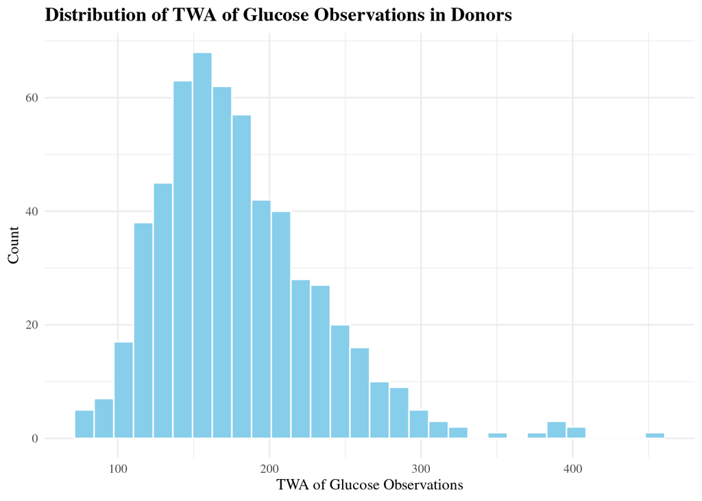

The distribution of TWA of glucose observations appear to be heavily right-skewed. This means that a majority of the donors did not have donor hyperglycemia.

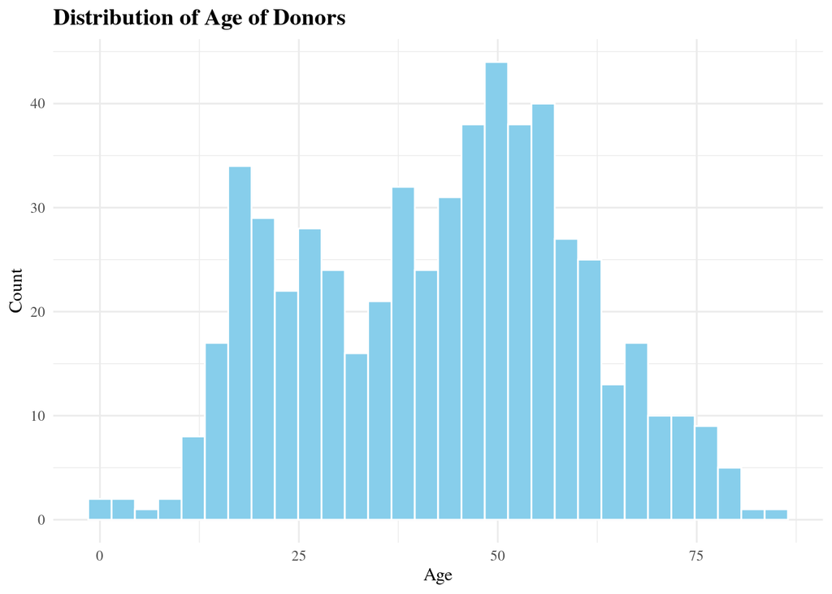

Interestingly, the distribution of age in the donors appear to be somewhat bimodal. This goes against intuition, which is that the distribution would be left-skewed (older people are more likely to die).

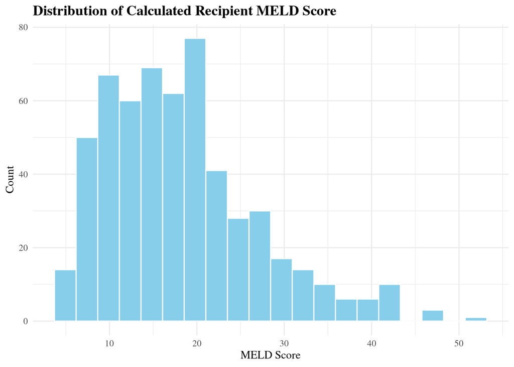

```
Call:
glm(formula = delayed_fn ~ glutwa + d_age + d_genderf + r_meld_calc +
    hemo_instability, family = "binomial", data = data)

Coefficients:
                     Estimate Std. Error z value Pr(>|z|)
(Intercept)         -2.155927   0.498322  -4.326 1.52e-05 ***
glutwa               0.002573   0.001777   1.448    0.148
d_age                0.005937   0.005977   0.993    0.321
d_genderfFemale      0.195980   0.207269   0.946    0.344
r_meld_calc          0.017291   0.011390   1.518    0.129
hemo_instabilityYes -0.048973   0.263508  -0.186    0.853
---
Signif. codes:  0 '***' 0.001 '**' 0.01 '*' 0.05 '.' 0.1 ' ' 1

(Dispersion parameter for binomial family taken to be 1)

    Null deviance: 617.73  on 542  degrees of freedom
Residual deviance: 610.65  on 537  degrees of freedom
  (29 observations deleted due to missingness)
AIC: 622.65

Number of Fisher Scoring iterations: 4
```

$\beta_0:$ -2.155927 represents the predicted delayed liver graft function log-odds of a recipient with a 0 MELD score and a donor that has 0 mg/dL TWA of glucose observations, is 0 years old, no intraoperative hemodynamic instability, and is male. This value is significant at the $\alpha = 0.05$ level.

$\beta_1:$ 0.002573 represents the predicted increase in delayed liver graft function log-odds for every one mg/dL increase in donor TWA of glucose observations, holding all other variables constant. This value is insignificant at the $\alpha = 0.05$ level.

$\beta_2:$ 0.005937 represents the predicted increase in delayed liver graft function log-odds for every one year increase in donor age, holding all other variables constant. This value is insignificant at the $\alpha = 0.05$ level.

$\beta_3:$ 0.195980 represents the predicted increase in delayed liver graft function log-odds of recipients with a donor that is female compared to those that are male, holding all other variables constant. This value is insignificant at the $\alpha = 0.05$ level.

$\beta_4:$ 0.017291 represents the predicted increase in delayed liver graft function log-odds for every one unit increase in calculated recipient MELD score, holding all other variables constant. This value is insignificant at the $\alpha = 0.05$ level.

$\beta_5:$ -0.048973 represents the predicted decrease in delayed liver graft function log-odds of donors that have intraoperative hemodynamic instability compared to those that do not have intraoperative hemodynamic instability, holding all other variables constant. This value is insignificant at the $\alpha = 0.05$ level.

# 5 **Discussion**

The goal of our research wasn’t met, as we intended to assess the relationship between donor hyperglycemia and liver function in the patient, and weren’t able to find conclusive evidence. Our initial hypothesis remains that higher donor TWA glucose is associated with increased log-odds of delayed graft function, assuming that donor hyperglycemia causes detrimental liver effects for the recipient. This data was obtained while all other variables were held constant, however the experiment also manipulated other factors of the donor and recipient to assess delayed liver graft function. We noticed that an increase in donor age, donor’s sex being female, and a higher recipient MELD score led to a predicted higher log-odds of delayed liver graft function. Donor intraoperative hemodynamic instability, on the other hand, correlated with a decreased predicted log-odds of delayed liver graft function. However, all these variables had p values higher than 𝛼 = 0.05 and are not statistically significant, so more research will be needed.

If we were to repeat this study or obtain our own data, we would take several steps to have a more robust scientific conclusion. Firstly, we wouldn’t assume linearity and might try to fit nonlinear models to our data to try to find the best possible fit and prediction. Additionally, we would perform sensitivity analyses to ensure that small changes in variables or data collection wouldn’t alter the data significantly. Lastly, if feasible, we would want to include more variables within our exploration so that we can predict potential confounding factors and see a wider range of potential changes to liver function. Some of these new variables may include the donor’s history of diabetes and cause of death, to better understand their health levels, as well as more information about the liver graft, such as preservation techniques and weight ratios to limit confounding variables. Altogether, these changes could allow for us to better our understanding of this issue in the future and promote research towards manipulating donor factors to prioritize healthy liver graft function.